# Risk Factor Analysis

## Outcome Variable

**Outcome Variable:** s03rec24

## Predictor Variables

**Intervention Variable:** enstunt

**Adjustment Set:**

unadjusted

## Stratifying Variables

The analysis was stratified on these variable(s):

- studyid
- country

## Data Summary

| studyid | country | A | n | nA | nAY0 | nAY1 |
| --- | --- | --- | --- | --- | --- | --- |
| ki0047075b-MAL-ED | BANGLADESH | 0 | 233 | 201 | 197 | 4 |
| ki0047075b-MAL-ED | BANGLADESH | 1 | 233 | 32 | 25 | 7 |
| ki0047075b-MAL-ED | BRAZIL | 0 | 179 | 166 | 158 | 8 |
| ki0047075b-MAL-ED | BRAZIL | 1 | 179 | 13 | 1 | 12 |
| ki0047075b-MAL-ED | INDIA | 0 | 199 | 171 | 164 | 7 |
| ki0047075b-MAL-ED | INDIA | 1 | 199 | 28 | 19 | 9 |
| ki0047075b-MAL-ED | NEPAL | 0 | 171 | 154 | 151 | 3 |
| ki0047075b-MAL-ED | NEPAL | 1 | 171 | 17 | 11 | 6 |
| ki0047075b-MAL-ED | PERU | 0 | 261 | 236 | 216 | 20 |
| ki0047075b-MAL-ED | PERU | 1 | 261 | 25 | 19 | 6 |
| ki0047075b-MAL-ED | SOUTH AFRICA | 0 | 249 | 229 | 212 | 17 |
| ki0047075b-MAL-ED | SOUTH AFRICA | 1 | 249 | 20 | 10 | 10 |
| ki0047075b-MAL-ED | TANZANIA, UNITED REPUBLIC OF | 0 | 119 | 104 | 104 | 0 |
| ki0047075b-MAL-ED | TANZANIA, UNITED REPUBLIC OF | 1 | 119 | 15 | 15 | 0 |
| ki1000108-CMC-V-BCS-2002 | INDIA | 0 | 98 | 82 | 78 | 4 |
| ki1000108-CMC-V-BCS-2002 | INDIA | 1 | 98 | 16 | 13 | 3 |
| ki1000108-IRC | INDIA | 0 | 410 | 362 | 333 | 29 |
| ki1000108-IRC | INDIA | 1 | 410 | 48 | 33 | 15 |
| ki1000109-EE | PAKISTAN | 0 | 3 | 3 | 3 | 0 |
| ki1000109-EE | PAKISTAN | 1 | 3 | 0 | 0 | 0 |
| ki1000109-ResPak | PAKISTAN | 0 | 32 | 32 | 32 | 0 |
| ki1000109-ResPak | PAKISTAN | 1 | 32 | 0 | 0 | 0 |
| ki1066203-TanzaniaChild2 | TANZANIA, UNITED REPUBLIC OF | 0 | 17 | 16 | 16 | 0 |
| ki1066203-TanzaniaChild2 | TANZANIA, UNITED REPUBLIC OF | 1 | 17 | 1 | 1 | 0 |
| ki1101329-Keneba | GAMBIA | 0 | 2430 | 2198 | 2076 | 122 |
| ki1101329-Keneba | GAMBIA | 1 | 2430 | 232 | 186 | 46 |
| ki1113344-GMS-Nepal | NEPAL | 0 | 52 | 43 | 42 | 1 |
| ki1113344-GMS-Nepal | NEPAL | 1 | 52 | 9 | 8 | 1 |
| ki1114097-CMIN | BANGLADESH | 0 | 7 | 7 | 7 | 0 |
| ki1114097-CMIN | BANGLADESH | 1 | 7 | 0 | 0 | 0 |
| ki1114097-CMIN | PERU | 0 | 99 | 97 | 97 | 0 |
| ki1114097-CMIN | PERU | 1 | 99 | 2 | 2 | 0 |
| ki1114097-CONTENT | PERU | 0 | 54 | 48 | 47 | 1 |
| ki1114097-CONTENT | PERU | 1 | 54 | 6 | 3 | 3 |

The following strata were considered:

- studyid: ki0047075b-MAL-ED, country: BANGLADESH
- studyid: ki0047075b-MAL-ED, country: BRAZIL
- studyid: ki0047075b-MAL-ED, country: INDIA
- studyid: ki0047075b-MAL-ED, country: NEPAL
- studyid: ki0047075b-MAL-ED, country: PERU
- studyid: ki0047075b-MAL-ED, country: SOUTH AFRICA
- studyid: ki0047075b-MAL-ED, country: TANZANIA, UNITED REPUBLIC OF
- studyid: ki1000108-CMC-V-BCS-2002, country: INDIA
- studyid: ki1000108-IRC, country: INDIA
- studyid: ki1000109-EE, country: PAKISTAN
- studyid: ki1000109-ResPak, country: PAKISTAN
- studyid: ki1066203-TanzaniaChild2, country: TANZANIA, UNITED REPUBLIC OF
- studyid: ki1101329-Keneba, country: GAMBIA
- studyid: ki1113344-GMS-Nepal, country: NEPAL
- studyid: ki1114097-CMIN, country: BANGLADESH
- studyid: ki1114097-CMIN, country: PERU
- studyid: ki1114097-CONTENT, country: PERU

### Dropped Strata

Some strata were dropped due to rare outcomes:

- studyid: ki0047075b-MAL-ED, country: BANGLADESH
- studyid: ki0047075b-MAL-ED, country: BRAZIL
- studyid: ki0047075b-MAL-ED, country: NEPAL
- studyid: ki0047075b-MAL-ED, country: TANZANIA, UNITED REPUBLIC OF
- studyid: ki1000108-CMC-V-BCS-2002, country: INDIA
- studyid: ki1000109-EE, country: PAKISTAN
- studyid: ki1000109-ResPak, country: PAKISTAN
- studyid: ki1066203-TanzaniaChild2, country: TANZANIA, UNITED REPUBLIC OF
- studyid: ki1113344-GMS-Nepal, country: NEPAL
- studyid: ki1114097-CMIN, country: BANGLADESH
- studyid: ki1114097-CMIN, country: PERU
- studyid: ki1114097-CONTENT, country: PERU

## Methods Detail

We’re interested in the causal parameters $E[Y_a]$ for all values of $a \in \mathcal{A}$. These parameters represent the mean outcome if, possibly contrary to fact, we intervened to set all units to have $A=a$. Under the randomization and positivity assumptions, these are identified by the statistical parameters $\psi_a=E_W[E_{Y|A,W}(Y|A=a,W)]$. In addition, we’re interested in the mean of $Y$, $E[Y]$ under no intervention (the observed mean). We will estimate these parameters by using SuperLearner to fit the relevant likelihood factors – $E_{Y|A,W}(Y|A=a,W)$ and $p(A=a|W)$, and then updating our likelihood fit using a joint TMLE.

For unadjusted analyses ($W=\{\}$), initial likelihoods were estimated using Lrnr_glm to estimate the simple $E(Y|A)$ and Lrnr_mean to estimate $p(A)$. For adjusted analyses, a small library containing Lrnr_glmnet, Lrnr_xgboost, and Lrnr_mean was used.

Having estimated these parameters, we will then use the delta method to estimate relative risks and attributable risks relative to a prespecified baseline level of $A$.

# Results Detail

## Results Plots

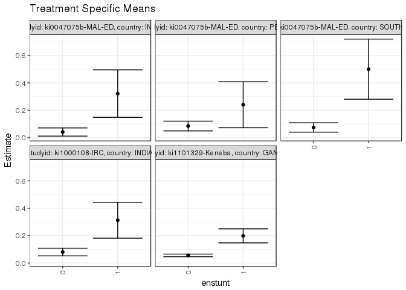

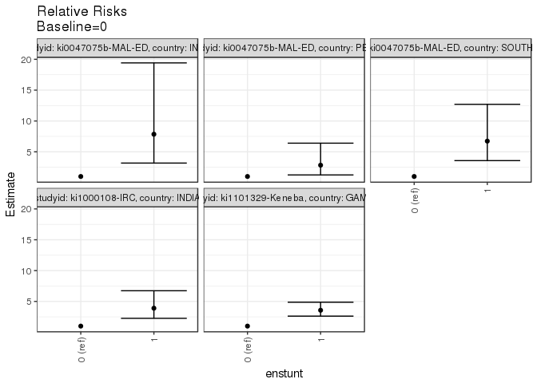

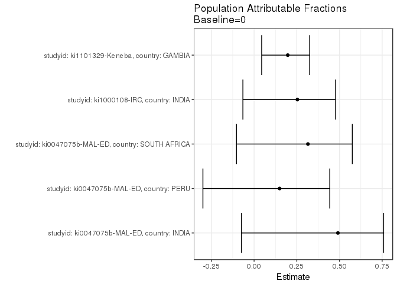

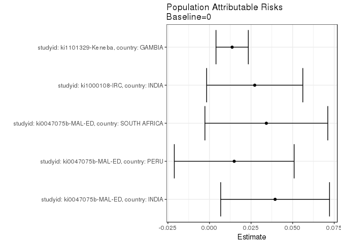

## Results Table

### Parameter: TSM

| studyid | country | intervention_level | baseline_level | estimate | ci_lower | ci_upper |
| --- | --- | --- | --- | --- | --- | --- |
| ki0047075b-MAL-ED | INDIA | 0 | NA | 0.0409357 | 0.0111629 | 0.0707084 |
| ki0047075b-MAL-ED | INDIA | 1 | NA | 0.3214286 | 0.1480070 | 0.4948501 |
| ki0047075b-MAL-ED | PERU | 0 | NA | 0.0847458 | 0.0491453 | 0.1203462 |
| ki0047075b-MAL-ED | PERU | 1 | NA | 0.2400000 | 0.0722648 | 0.4077352 |
| ki0047075b-MAL-ED | SOUTH AFRICA | 0 | NA | 0.0742358 | 0.0402137 | 0.1082579 |
| ki0047075b-MAL-ED | SOUTH AFRICA | 1 | NA | 0.5000000 | 0.2804280 | 0.7195720 |
| ki1000108-IRC | INDIA | 0 | NA | 0.0801105 | 0.0521119 | 0.1081091 |
| ki1000108-IRC | INDIA | 1 | NA | 0.3125000 | 0.1812138 | 0.4437862 |
| ki1101329-Keneba | GAMBIA | 0 | NA | 0.0555050 | 0.0459311 | 0.0650789 |
| ki1101329-Keneba | GAMBIA | 1 | NA | 0.1982759 | 0.1469613 | 0.2495905 |

### Parameter: E(Y)

| studyid | country | intervention_level | baseline_level | estimate | ci_lower | ci_upper |
| --- | --- | --- | --- | --- | --- | --- |
| ki0047075b-MAL-ED | INDIA | NA | NA | 0.0804020 | 0.0668170 | 0.0939871 |
| ki0047075b-MAL-ED | PERU | NA | NA | 0.0996169 | 0.0940631 | 0.1051707 |
| ki0047075b-MAL-ED | SOUTH AFRICA | NA | NA | 0.1084337 | 0.0940317 | 0.1228358 |
| ki1000108-IRC | INDIA | NA | NA | 0.1073171 | 0.1000761 | 0.1145580 |
| ki1101329-Keneba | GAMBIA | NA | NA | 0.0691358 | 0.0674673 | 0.0708043 |

### Parameter: RR

| studyid | country | intervention_level | baseline_level | estimate | ci_lower | ci_upper |
| --- | --- | --- | --- | --- | --- | --- |
| ki0047075b-MAL-ED | INDIA | 0 | 0 | 1.000000 | 1.000000 | 1.000000 |
| ki0047075b-MAL-ED | INDIA | 1 | 0 | 7.852041 | 3.174647 | 19.420915 |
| ki0047075b-MAL-ED | PERU | 0 | 0 | 1.000000 | 1.000000 | 1.000000 |
| ki0047075b-MAL-ED | PERU | 1 | 0 | 2.832000 | 1.253014 | 6.400745 |
| ki0047075b-MAL-ED | SOUTH AFRICA | 0 | 0 | 1.000000 | 1.000000 | 1.000000 |
| ki0047075b-MAL-ED | SOUTH AFRICA | 1 | 0 | 6.735294 | 3.570229 | 12.706238 |
| ki1000108-IRC | INDIA | 0 | 0 | 1.000000 | 1.000000 | 1.000000 |
| ki1000108-IRC | INDIA | 1 | 0 | 3.900862 | 2.258523 | 6.737468 |
| ki1101329-Keneba | GAMBIA | 0 | 0 | 1.000000 | 1.000000 | 1.000000 |
| ki1101329-Keneba | GAMBIA | 1 | 0 | 3.572216 | 2.617368 | 4.875404 |

### Parameter: PAR

| studyid | country | intervention_level | baseline_level | estimate | ci_lower | ci_upper |
| --- | --- | --- | --- | --- | --- | --- |
| ki0047075b-MAL-ED | INDIA | 0 | NA | 0.0394663 | 0.0067407 | 0.0721920 |
| ki0047075b-MAL-ED | PERU | 0 | NA | 0.0148711 | -0.0211600 | 0.0509022 |
| ki0047075b-MAL-ED | SOUTH AFRICA | 0 | NA | 0.0341979 | -0.0027469 | 0.0711428 |
| ki1000108-IRC | INDIA | 0 | NA | 0.0272066 | -0.0017132 | 0.0561264 |
| ki1101329-Keneba | GAMBIA | 0 | NA | 0.0136308 | 0.0039126 | 0.0233490 |

### Parameter: PAF

| studyid | country | intervention_level | baseline_level | estimate | ci_lower | ci_upper |
| --- | --- | --- | --- | --- | --- | --- |
| ki0047075b-MAL-ED | INDIA | 0 | NA | 0.4908626 | -0.0742651 | 0.7586993 |
| ki0047075b-MAL-ED | PERU | 0 | NA | 0.1492829 | -0.2996475 | 0.4431417 |
| ki0047075b-MAL-ED | SOUTH AFRICA | 0 | NA | 0.3153809 | -0.1032531 | 0.5751625 |
| ki1000108-IRC | INDIA | 0 | NA | 0.2535158 | -0.0656367 | 0.4770839 |
| ki1101329-Keneba | GAMBIA | 0 | NA | 0.1971598 | 0.0444154 | 0.3254889 |